# Starbucks Capstone Challenge

### Introduction

This data set contains simulated data that mimics customer behavior on the Starbucks rewards mobile app. Once every few days, Starbucks sends out an offer to users of the mobile app. An offer can be merely an advertisement for a drink or an actual offer such as a discount or BOGO (buy one get one free). Some users might not receive any offer during certain weeks.

Not all users receive the same offer, and that is the challenge to solve with this data set.

Your task is to combine transaction, demographic and offer data to determine which demographic groups respond best to which offer type. This data set is a simplified version of the real Starbucks app because the underlying simulator only has one product whereas Starbucks actually sells dozens of products.

Every offer has a validity period before the offer expires. As an example, a BOGO offer might be valid for only 5 days. You'll see in the data set that informational offers have a validity period even though these ads are merely providing information about a product; for example, if an informational offer has 7 days of validity, you can assume the customer is feeling the influence of the offer for 7 days after receiving the advertisement.

You'll be given transactional data showing user purchases made on the app including the timestamp of purchase and the amount of money spent on a purchase. This transactional data also has a record for each offer that a user receives as well as a record for when a user actually views the offer. There are also records for when a user completes an offer.

Keep in mind as well that someone using the app might make a purchase through the app without having received an offer or seen an offer.

### Example

To give an example, a user could receive a discount offer buy 10 dollars get 2 off on Monday. The offer is valid for 10 days from receipt. If the customer accumulates at least 10 dollars in purchases during the validity period, the customer completes the offer.

However, there are a few things to watch out for in this data set. Customers do not opt into the offers that they receive; in other words, a user can receive an offer, never actually view the offer, and still complete the offer. For example, a user might receive the "buy 10 dollars get 2 dollars off offer", but the user never opens the offer during the 10 day validity period. The customer spends 15 dollars during those ten days. There will be an offer completion record in the data set; however, the customer was not influenced by the offer because the customer never viewed the offer.

### Cleaning

This makes data cleaning especially important and tricky.

You'll also want to take into account that some demographic groups will make purchases even if they don't receive an offer. From a business perspective, if a customer is going to make a 10 dollar purchase without an offer anyway, you wouldn't want to send a buy 10 dollars get 2 dollars off offer. You'll want to try to assess what a certain demographic group will buy when not receiving any offers.

### Final Advice

Because this is a capstone project, you are free to analyze the data any way you see fit. For example, you could build a machine learning model that predicts how much someone will spend based on demographics and offer type. Or you could build a model that predicts whether or not someone will respond to an offer. Or, you don't need to build a machine learning model at all. You could develop a set of heuristics that determine what offer you should send to each customer (i.e., 75 percent of women customers who were 35 years old responded to offer A vs 40 percent from the same demographic to offer B, so send offer A).

# Data Sets

The data is contained in three files:

- portfolio.json - containing offer ids and meta data about each offer (duration, type, etc.)
- profile.json - demographic data for each customer
- transcript.json - records for transactions, offers received, offers viewed, and offers completed

Here is the schema and explanation of each variable in the files:

**portfolio.json**

- id (string) - offer id
- offer_type (string) - type of offer ie BOGO, discount, informational
- difficulty (int) - minimum required spend to complete an offer
- reward (int) - reward given for completing an offer
- duration (int) - time for offer to be open, in days
- channels (list of strings)

**profile.json**

- age (int) - age of the customer
- became_member_on (int) - date when customer created an app account
- gender (str) - gender of the customer (note some entries contain 'O' for other rather than M or F)
- id (str) - customer id
- income (float) - customer's income

**transcript.json**

- event (str) - record description (ie transaction, offer received, offer viewed, etc.)
- person (str) - customer id
- time (int) - time in hours since start of test. The data begins at time t=0
- value - (dict of strings) - either an offer id or transaction amount depending on the record

**Note:** If you are using the workspace, you will need to go to the terminal and run the command `conda update pandas` before reading in the files. This is because the version of pandas in the workspace cannot read in the transcript.json file correctly, but the newest version of pandas can. You can access the termnal from the orange icon in the top left of this notebook.

You can see how to access the terminal and how the install works using the two images below. First you need to access the terminal:

[figure not shown]

Then you will want to run the above command:

[figure not shown]

Finally, when you enter back into the notebook (use the jupyter icon again), you should be able to run the below cell without any errors.

```python
import pandas as pd
import numpy as np
import math
import json
% matplotlib inline

# read in the json files
portfolio = pd.read_json('data/portfolio.json', orient='records', lines=True)
profile = pd.read_json('data/profile.json', orient='records', lines=True)
transcript = pd.read_json('data/transcript.json', orient='records', lines=True)
```

```python
import matplotlib.pyplot as plt
import seaborn as sns
```

```python
from sklearn.preprocessing import StandardScaler
from sklearn.model_selection import train_test_split
import tensorflow as tf
import keras
```

```python
portfolio.head(1)
```

|  | channels | difficulty | duration | id | offer_type | reward |
| --- | --- | --- | --- | --- | --- | --- |
| 0 | [email, mobile, social] | 10 | 7 | ae264e3637204a6fb9bb56bc8210ddfd | bogo | 10 |

```python
profile.head(1)
```

|  | age | became_member_on | gender | id | income |
| --- | --- | --- | --- | --- | --- |
| 0 | 118 | 20170212 | None | 68be06ca386d4c31939f3a4f0e3dd783 | NaN |

```python
transcript.head(1)
```

|  | event | person | time | value |
| --- | --- | --- | --- | --- |
| 0 | offer received | 78afa995795e4d85b5d9ceeca43f5fef | 0 | {'offer id': '9b98b8c7a33c4b65b9aebfe6a799e6d9'} |

# Data Accessing and Cleaning :

## Portfolio Data

```python
portfolio.shape
```

```
(10, 6)
```

```python
portfolio.info()
```

```
<class 'pandas.core.frame.DataFrame'>
RangeIndex: 10 entries, 0 to 9
Data columns (total 6 columns):
channels      10 non-null object
difficulty    10 non-null int64
duration      10 non-null int64
id            10 non-null object
offer_type    10 non-null object
reward        10 non-null int64
dtypes: int64(3), object(3)
memory usage: 560.0+ bytes
```

```python
portfolio.describe()
```

|  | difficulty | duration | reward |
| --- | --- | --- | --- |
| count | 10.000000 | 10.000000 | 10.000000 |
| mean | 7.700000 | 6.500000 | 4.200000 |
| std | 5.831905 | 2.321398 | 3.583915 |
| min | 0.000000 | 3.000000 | 0.000000 |
| 25% | 5.000000 | 5.000000 | 2.000000 |
| 50% | 8.500000 | 7.000000 | 4.000000 |
| 75% | 10.000000 | 7.000000 | 5.000000 |
| max | 20.000000 | 10.000000 | 10.000000 |

```python
portfolio['channels']
```

```
0         [email, mobile, social]
1    [web, email, mobile, social]
2            [web, email, mobile]
3            [web, email, mobile]
4                    [web, email]
5    [web, email, mobile, social]
6    [web, email, mobile, social]
7         [email, mobile, social]
8    [web, email, mobile, social]
9            [web, email, mobile]
Name: channels, dtype: object
```

### - Data Cleaning

```python
df1 = portfolio.copy()
```

```python
dummy = pd.get_dummies(df1.channels.apply(pd.Series).stack()).sum(level=0)
df1 = pd.concat([df1, dummy], axis=1)
df1 = df1.drop(columns='channels')
```

```python
df1 = df1.rename(columns={'id':'offer_id'})
```

```python
df1
```

|  | difficulty | duration | offer_id | offer_type | reward | email | mobile | social | web |
| --- | --- | --- | --- | --- | --- | --- | --- | --- | --- |
| 0 | 10 | 7 | ae264e3637204a6fb9bb56bc8210ddfd | bogo | 10 | 1 | 1 | 1 | 0 |
| 1 | 10 | 5 | 4d5c57ea9a6940dd891ad53e9dbe8da0 | bogo | 10 | 1 | 1 | 1 | 1 |
| 2 | 0 | 4 | 3f207df678b143eea3cee63160fa8bed | informational | 0 | 1 | 1 | 0 | 1 |
| 3 | 5 | 7 | 9b98b8c7a33c4b65b9aebfe6a799e6d9 | bogo | 5 | 1 | 1 | 0 | 1 |
| 4 | 20 | 10 | 0b1e1539f2cc45b7b9fa7c272da2e1d7 | discount | 5 | 1 | 0 | 0 | 1 |
| 5 | 7 | 7 | 2298d6c36e964ae4a3e7e9706d1fb8c2 | discount | 3 | 1 | 1 | 1 | 1 |
| 6 | 10 | 10 | fafdcd668e3743c1bb461111dcafc2a4 | discount | 2 | 1 | 1 | 1 | 1 |
| 7 | 0 | 3 | 5a8bc65990b245e5a138643cd4eb9837 | informational | 0 | 1 | 1 | 1 | 0 |
| 8 | 5 | 5 | f19421c1d4aa40978ebb69ca19b0e20d | bogo | 5 | 1 | 1 | 1 | 1 |
| 9 | 10 | 7 | 2906b810c7d4411798c6938adc9daaa5 | discount | 2 | 1 | 1 | 0 | 1 |

## 2. Profile Data

```python
profile.shape
```

```
(17000, 5)
```

```python
profile.info()
```

```
<class 'pandas.core.frame.DataFrame'>
RangeIndex: 17000 entries, 0 to 16999
Data columns (total 5 columns):
age                 17000 non-null int64
became_member_on    17000 non-null int64
gender              14825 non-null object
id                  17000 non-null object
income              14825 non-null float64
dtypes: float64(1), int64(2), object(2)
memory usage: 664.1+ KB
```

```python
profile.describe()
```

|  | age | became_member_on | income |
| --- | --- | --- | --- |
| count | 17000.000000 | 1.700000e+04 | 14825.000000 |
| mean | 62.531412 | 2.016703e+07 | 65404.991568 |
| std | 26.738580 | 1.167750e+04 | 21598.299410 |
| min | 18.000000 | 2.013073e+07 | 30000.000000 |
| 25% | 45.000000 | 2.016053e+07 | 49000.000000 |
| 50% | 58.000000 | 2.017080e+07 | 64000.000000 |
| 75% | 73.000000 | 2.017123e+07 | 80000.000000 |
| max | 118.000000 | 2.018073e+07 | 120000.000000 |

```python
profile.duplicated().sum()
```

```
0
```

### - Data Cleaning

```python
df2 = profile.copy()
```

```python
df2['became_member_on'] = pd.to_datetime(df2['became_member_on'], format='%Y%m%d')
```

```python
df2 = df2.rename(columns={'id':'customer_id'})
```

```python
df2.head(10)
```

|  | age | became_member_on | gender | customer_id | income |
| --- | --- | --- | --- | --- | --- |
| 0 | 118 | 2017-02-12 | None | 68be06ca386d4c31939f3a4f0e3dd783 | NaN |
| 1 | 55 | 2017-07-15 | F | 0610b486422d4921ae7d2bf64640c50b | 112000.0 |
| 2 | 118 | 2018-07-12 | None | 38fe809add3b4fcf9315a9694bb96ff5 | NaN |
| 3 | 75 | 2017-05-09 | F | 78afa995795e4d85b5d9ceeca43f5fef | 100000.0 |
| 4 | 118 | 2017-08-04 | None | a03223e636434f42ac4c3df47e8bac43 | NaN |
| 5 | 68 | 2018-04-26 | M | e2127556f4f64592b11af22de27a7932 | 70000.0 |
| 6 | 118 | 2017-09-25 | None | 8ec6ce2a7e7949b1bf142def7d0e0586 | NaN |
| 7 | 118 | 2017-10-02 | None | 68617ca6246f4fbc85e91a2a49552598 | NaN |
| 8 | 65 | 2018-02-09 | M | 389bc3fa690240e798340f5a15918d5c | 53000.0 |
| 9 | 118 | 2016-11-22 | None | 8974fc5686fe429db53ddde067b88302 | NaN |

```python
type(df2.became_member_on[0])
```

```
pandas._libs.tslibs.timestamps.Timestamp
```

## 3. Transcript Data

```python
transcript.head()
```

|  | event | person | time | value |
| --- | --- | --- | --- | --- |
| 0 | offer received | 78afa995795e4d85b5d9ceeca43f5fef | 0 | {'offer id': '9b98b8c7a33c4b65b9aebfe6a799e6d9'} |
| 1 | offer received | a03223e636434f42ac4c3df47e8bac43 | 0 | {'offer id': '0b1e1539f2cc45b7b9fa7c272da2e1d7'} |
| 2 | offer received | e2127556f4f64592b11af22de27a7932 | 0 | {'offer id': '2906b810c7d4411798c6938adc9daaa5'} |
| 3 | offer received | 8ec6ce2a7e7949b1bf142def7d0e0586 | 0 | {'offer id': 'fafdcd668e3743c1bb461111dcafc2a4'} |
| 4 | offer received | 68617ca6246f4fbc85e91a2a49552598 | 0 | {'offer id': '4d5c57ea9a6940dd891ad53e9dbe8da0'} |

```python
transcript.shape
```

```
(306534, 4)
```

```python
transcript.info()
```

```
<class 'pandas.core.frame.DataFrame'>
RangeIndex: 306534 entries, 0 to 306533
Data columns (total 4 columns):
event     306534 non-null object
person    306534 non-null object
time      306534 non-null int64
value     306534 non-null object
dtypes: int64(1), object(3)
memory usage: 9.4+ MB
```

```python
transcript.describe()
```

|  | time |
| --- | --- |
| count | 306534.000000 |
| mean | 366.382940 |
| std | 200.326314 |
| min | 0.000000 |
| 25% | 186.000000 |
| 50% | 408.000000 |
| 75% | 528.000000 |
| max | 714.000000 |

```python
transcript['value']
```

```
0          {'offer id': '9b98b8c7a33c4b65b9aebfe6a799e6d9'}
1          {'offer id': '0b1e1539f2cc45b7b9fa7c272da2e1d7'}
2          {'offer id': '2906b810c7d4411798c6938adc9daaa5'}
3          {'offer id': 'fafdcd668e3743c1bb461111dcafc2a4'}
4          {'offer id': '4d5c57ea9a6940dd891ad53e9dbe8da0'}
5          {'offer id': 'f19421c1d4aa40978ebb69ca19b0e20d'}
6          {'offer id': '2298d6c36e964ae4a3e7e9706d1fb8c2'}
7          {'offer id': '3f207df678b143eea3cee63160fa8bed'}
8          {'offer id': '0b1e1539f2cc45b7b9fa7c272da2e1d7'}
9          {'offer id': '0b1e1539f2cc45b7b9fa7c272da2e1d7'}
10         {'offer id': '0b1e1539f2cc45b7b9fa7c272da2e1d7'}
11         {'offer id': '0b1e1539f2cc45b7b9fa7c272da2e1d7'}
12         {'offer id': 'ae264e3637204a6fb9bb56bc8210ddfd'}
13         {'offer id': '3f207df678b143eea3cee63160fa8bed'}
14         {'offer id': '0b1e1539f2cc45b7b9fa7c272da2e1d7'}
```

[output cut: 47 more lines]

```python
transcript['value'].value_counts()
```

[output not shown]

```python
transcript['event'].unique()
```

```
array(['offer received', 'offer viewed', 'transaction', 'offer completed'], dtype=object)
```

```python
transcript['event'].value_counts()
```

```
transaction        138953
offer received      76277
offer viewed        57725
offer completed     33579
Name: event, dtype: int64
```

### - Data Cleaning

```python
df3 = transcript.copy()
```

```python
df3 = df3.rename(columns={'person':'customer_id'})
```

```python
df3['event'] = df3['event'].str.replace(' ', '-')
```

```python
df3['event'].value_counts()
```

```
transaction        138953
offer-received      76277
offer-viewed        57725
offer-completed     33579
Name: event, dtype: int64
```

```python
dummy = pd.get_dummies(df3['event'])
df3 = pd.concat([df3, dummy], axis=1 )
```

```python
df3['offer_id'] = [[*i.values()][0]if [*i.keys()][0] in ['offer id','offer_id'] else None for i in df3.value]
df3['amount'] = [np.round([*i.values()][0], decimals=2)if [*i.keys()][0] == 'amount' else None for i in df3.value]
```

```python
df3 = df3.drop(columns='value')
```

### - Data Cleaning :

```python
t_p = pd.merge(df3, df2, on='customer_id')
```

```python
t_p
```

|  | event | customer_id | time | offer-completed | offer-received | offer-viewed | transaction | offer_id | amount | age | became_member_on | gender | income |
| --- | --- | --- | --- | --- | --- | --- | --- | --- | --- | --- | --- | --- | --- |
| 0 | offer-received | 78afa995795e4d85b5d9ceeca43f5fef | 0 | 0 | 1 | 0 | 0 | 9b98b8c7a33c4b65b9aebfe6a799e6d9 | NaN | 75 | 2017-05-09 | F | 100000.0 |
| 1 | offer-viewed | 78afa995795e4d85b5d9ceeca43f5fef | 6 | 0 | 0 | 1 | 0 | 9b98b8c7a33c4b65b9aebfe6a799e6d9 | NaN | 75 | 2017-05-09 | F | 100000.0 |
| 2 | transaction | 78afa995795e4d85b5d9ceeca43f5fef | 132 | 0 | 0 | 0 | 1 | None | 19.89 | 75 | 2017-05-09 | F | 100000.0 |
| 3 | offer-completed | 78afa995795e4d85b5d9ceeca43f5fef | 132 | 1 | 0 | 0 | 0 | 9b98b8c7a33c4b65b9aebfe6a799e6d9 | NaN | 75 | 2017-05-09 | F | 100000.0 |
| 4 | transaction | 78afa995795e4d85b5d9ceeca43f5fef | 144 | 0 | 0 | 0 | 1 | None | 17.78 | 75 | 2017-05-09 | F | 100000.0 |
| 5 | offer-received | 78afa995795e4d85b5d9ceeca43f5fef | 168 | 0 | 1 | 0 | 0 | 5a8bc65990b245e5a138643cd4eb9837 | NaN | 75 | 2017-05-09 | F | 100000.0 |
| 6 | offer-viewed | 78afa995795e4d85b5d9ceeca43f5fef | 216 | 0 | 0 | 1 | 0 | 5a8bc65990b245e5a138643cd4eb9837 | NaN | 75 | 2017-05-09 | F | 100000.0 |
| 7 | transaction | 78afa995795e4d85b5d9ceeca43f5fef | 222 | 0 | 0 | 0 | 1 | None | 19.67 | 75 | 2017-05-09 | F | 100000.0 |
| 8 | transaction | 78afa995795e4d85b5d9ceeca43f5fef | 240 | 0 | 0 | 0 | 1 | None | 29.72 | 75 | 2017-05-09 | F | 100000.0 |
| 9 | transaction | 78afa995795e4d85b5d9ceeca43f5fef | 378 | 0 | 0 | 0 | 1 | None | 23.93 | 75 | 2017-05-09 | F | 100000.0 |
| 10 | offer-received | 78afa995795e4d85b5d9ceeca43f5fef | 408 | 0 | 1 | 0 | 0 | ae264e3637204a6fb9bb56bc8210ddfd | NaN | 75 | 2017-05-09 | F | 100000.0 |
| 11 | offer-viewed | 78afa995795e4d85b5d9ceeca43f5fef | 408 | 0 | 0 | 1 | 0 | ae264e3637204a6fb9bb56bc8210ddfd | NaN | 75 | 2017-05-09 | F | 100000.0 |
| 12 | offer-received | 78afa995795e4d85b5d9ceeca43f5fef | 504 | 0 | 1 | 0 | 0 | f19421c1d4aa40978ebb69ca19b0e20d | NaN | 75 | 2017-05-09 | F | 100000.0 |
| 13 | transaction | 78afa995795e4d85b5d9ceeca43f5fef | 510 | 0 | 0 | 0 | 1 | None | 21.72 | 75 | 2017-05-09 | F | 100000.0 |
| 14 | offer-completed | 78afa995795e4d85b5d9ceeca43f5fef | 510 | 1 | 0 | 0 | 0 | ae264e3637204a6fb9bb56bc8210ddfd | NaN | 75 | 2017-05-09 | F | 100000.0 |
| 15 | offer-completed | 78afa995795e4d85b5d9ceeca43f5fef | 510 | 1 | 0 | 0 | 0 | f19421c1d4aa40978ebb69ca19b0e20d | NaN | 75 | 2017-05-09 | F | 100000.0 |
| 16 | transaction | 78afa995795e4d85b5d9ceeca43f5fef | 534 | 0 | 0 | 0 | 1 | None | 26.56 | 75 | 2017-05-09 | F | 100000.0 |
| 17 | offer-viewed | 78afa995795e4d85b5d9ceeca43f5fef | 582 | 0 | 0 | 1 | 0 | f19421c1d4aa40978ebb69ca19b0e20d | NaN | 75 | 2017-05-09 | F | 100000.0 |
| 18 | offer-received | a03223e636434f42ac4c3df47e8bac43 | 0 | 0 | 1 | 0 | 0 | 0b1e1539f2cc45b7b9fa7c272da2e1d7 | NaN | 118 | 2017-08-04 | None | NaN |
| 19 | offer-viewed | a03223e636434f42ac4c3df47e8bac43 | 6 | 0 | 0 | 1 | 0 | 0b1e1539f2cc45b7b9fa7c272da2e1d7 | NaN | 118 | 2017-08-04 | None | NaN |
| 20 | transaction | a03223e636434f42ac4c3df47e8bac43 | 234 | 0 | 0 | 0 | 1 | None | 1.09 | 118 | 2017-08-04 | None | NaN |
| 21 | transaction | a03223e636434f42ac4c3df47e8bac43 | 264 | 0 | 0 | 0 | 1 | None | 3.50 | 118 | 2017-08-04 | None | NaN |
| 22 | offer-received | a03223e636434f42ac4c3df47e8bac43 | 336 | 0 | 1 | 0 | 0 | 3f207df678b143eea3cee63160fa8bed | NaN | 118 | 2017-08-04 | None | NaN |
| 23 | offer-viewed | a03223e636434f42ac4c3df47e8bac43 | 336 | 0 | 0 | 1 | 0 | 3f207df678b143eea3cee63160fa8bed | NaN | 118 | 2017-08-04 | None | NaN |
| 24 | offer-received | a03223e636434f42ac4c3df47e8bac43 | 408 | 0 | 1 | 0 | 0 | 5a8bc65990b245e5a138643cd4eb9837 | NaN | 118 | 2017-08-04 | None | NaN |
| 25 | offer-received | a03223e636434f42ac4c3df47e8bac43 | 504 | 0 | 1 | 0 | 0 | 0b1e1539f2cc45b7b9fa7c272da2e1d7 | NaN | 118 | 2017-08-04 | None | NaN |
| 26 | offer-received | a03223e636434f42ac4c3df47e8bac43 | 576 | 0 | 1 | 0 | 0 | 0b1e1539f2cc45b7b9fa7c272da2e1d7 | NaN | 118 | 2017-08-04 | None | NaN |
| 27 | transaction | a03223e636434f42ac4c3df47e8bac43 | 612 | 0 | 0 | 0 | 1 | None | 0.06 | 118 | 2017-08-04 | None | NaN |
| 28 | offer-viewed | a03223e636434f42ac4c3df47e8bac43 | 624 | 0 | 0 | 1 | 0 | 0b1e1539f2cc45b7b9fa7c272da2e1d7 | NaN | 118 | 2017-08-04 | None | NaN |
| 29 | offer-received | e2127556f4f64592b11af22de27a7932 | 0 | 0 | 1 | 0 | 0 | 2906b810c7d4411798c6938adc9daaa5 | NaN | 68 | 2018-04-26 | M | 70000.0 |
| ... | ... | ... | ... | ... | ... | ... | ... | ... | ... | ... | ... | ... | ... |
| 306504 | offer-received | 47683732768a4f7db7abb710ca22e66e | 504 | 0 | 1 | 0 | 0 | ae264e3637204a6fb9bb56bc8210ddfd | NaN | 24 | 2017-11-08 | M | 56000.0 |
| 306505 | offer-viewed | 47683732768a4f7db7abb710ca22e66e | 540 | 0 | 0 | 1 | 0 | ae264e3637204a6fb9bb56bc8210ddfd | NaN | 24 | 2017-11-08 | M | 56000.0 |
| 306506 | offer-received | 47683732768a4f7db7abb710ca22e66e | 576 | 0 | 1 | 0 | 0 | ae264e3637204a6fb9bb56bc8210ddfd | NaN | 24 | 2017-11-08 | M | 56000.0 |
| 306507 | offer-viewed | 47683732768a4f7db7abb710ca22e66e | 630 | 0 | 0 | 1 | 0 | ae264e3637204a6fb9bb56bc8210ddfd | NaN | 24 | 2017-11-08 | M | 56000.0 |
| 306508 | transaction | 47683732768a4f7db7abb710ca22e66e | 684 | 0 | 0 | 0 | 1 | None | 7.10 | 24 | 2017-11-08 | M | 56000.0 |
| 306509 | offer-received | 3873fe915496482eb589fa316ae7b0db | 504 | 0 | 1 | 0 | 0 | ae264e3637204a6fb9bb56bc8210ddfd | NaN | 58 | 2017-09-05 | M | 57000.0 |
| 306510 | offer-viewed | 3873fe915496482eb589fa316ae7b0db | 510 | 0 | 0 | 1 | 0 | ae264e3637204a6fb9bb56bc8210ddfd | NaN | 58 | 2017-09-05 | M | 57000.0 |
| 306511 | transaction | 3873fe915496482eb589fa316ae7b0db | 510 | 0 | 0 | 0 | 1 | None | 1.57 | 58 | 2017-09-05 | M | 57000.0 |
| 306512 | offer-received | 3873fe915496482eb589fa316ae7b0db | 576 | 0 | 1 | 0 | 0 | f19421c1d4aa40978ebb69ca19b0e20d | NaN | 58 | 2017-09-05 | M | 57000.0 |
| 306513 | offer-viewed | 3873fe915496482eb589fa316ae7b0db | 582 | 0 | 0 | 1 | 0 | f19421c1d4aa40978ebb69ca19b0e20d | NaN | 58 | 2017-09-05 | M | 57000.0 |
| 306514 | transaction | 3873fe915496482eb589fa316ae7b0db | 588 | 0 | 0 | 0 | 1 | None | 1.21 | 58 | 2017-09-05 | M | 57000.0 |
| 306515 | transaction | 3873fe915496482eb589fa316ae7b0db | 612 | 0 | 0 | 0 | 1 | None | 2.65 | 58 | 2017-09-05 | M | 57000.0 |
| 306516 | offer-received | 8578196a074a4f328976e334fa9383a3 | 504 | 0 | 1 | 0 | 0 | 4d5c57ea9a6940dd891ad53e9dbe8da0 | NaN | 48 | 2018-06-10 | M | 58000.0 |
| 306517 | offer-viewed | 8578196a074a4f328976e334fa9383a3 | 504 | 0 | 0 | 1 | 0 | 4d5c57ea9a6940dd891ad53e9dbe8da0 | NaN | 48 | 2018-06-10 | M | 58000.0 |
| 306518 | offer-received | 8578196a074a4f328976e334fa9383a3 | 576 | 0 | 1 | 0 | 0 | 2906b810c7d4411798c6938adc9daaa5 | NaN | 48 | 2018-06-10 | M | 58000.0 |
| 306519 | transaction | 8578196a074a4f328976e334fa9383a3 | 702 | 0 | 0 | 0 | 1 | None | 4.62 | 48 | 2018-06-10 | M | 58000.0 |
| 306520 | offer-received | 9fcbff4f8d7241faa4ab8a9d19c8a812 | 504 | 0 | 1 | 0 | 0 | 3f207df678b143eea3cee63160fa8bed | NaN | 47 | 2017-10-13 | M | 94000.0 |
| 306521 | offer-viewed | 9fcbff4f8d7241faa4ab8a9d19c8a812 | 504 | 0 | 0 | 1 | 0 | 3f207df678b143eea3cee63160fa8bed | NaN | 47 | 2017-10-13 | M | 94000.0 |
| 306522 | offer-received | 9fcbff4f8d7241faa4ab8a9d19c8a812 | 576 | 0 | 1 | 0 | 0 | 4d5c57ea9a6940dd891ad53e9dbe8da0 | NaN | 47 | 2017-10-13 | M | 94000.0 |
| 306523 | offer-viewed | 9fcbff4f8d7241faa4ab8a9d19c8a812 | 576 | 0 | 0 | 1 | 0 | 4d5c57ea9a6940dd891ad53e9dbe8da0 | NaN | 47 | 2017-10-13 | M | 94000.0 |
| 306524 | transaction | ebae5093b436466c9fbd097cb7434023 | 516 | 0 | 0 | 0 | 1 | None | 2.57 | 118 | 2017-12-03 | None | NaN |
| 306525 | offer-received | ebae5093b436466c9fbd097cb7434023 | 576 | 0 | 1 | 0 | 0 | fafdcd668e3743c1bb461111dcafc2a4 | NaN | 118 | 2017-12-03 | None | NaN |
| 306526 | offer-viewed | ebae5093b436466c9fbd097cb7434023 | 588 | 0 | 0 | 1 | 0 | fafdcd668e3743c1bb461111dcafc2a4 | NaN | 118 | 2017-12-03 | None | NaN |
| 306527 | transaction | ebae5093b436466c9fbd097cb7434023 | 660 | 0 | 0 | 0 | 1 | None | 12.64 | 118 | 2017-12-03 | None | NaN |
| 306528 | offer-completed | ebae5093b436466c9fbd097cb7434023 | 660 | 1 | 0 | 0 | 0 | fafdcd668e3743c1bb461111dcafc2a4 | NaN | 118 | 2017-12-03 | None | NaN |
| 306529 | offer-received | 912b9f623b9e4b4eb99b6dc919f09a93 | 576 | 0 | 1 | 0 | 0 | 4d5c57ea9a6940dd891ad53e9dbe8da0 | NaN | 118 | 2017-09-26 | None | NaN |
| 306530 | offer-viewed | 912b9f623b9e4b4eb99b6dc919f09a93 | 594 | 0 | 0 | 1 | 0 | 4d5c57ea9a6940dd891ad53e9dbe8da0 | NaN | 118 | 2017-09-26 | None | NaN |
| 306531 | offer-received | 3045af4e98794a04a5542d3eac939b1f | 576 | 0 | 1 | 0 | 0 | 4d5c57ea9a6940dd891ad53e9dbe8da0 | NaN | 58 | 2016-10-20 | F | 78000.0 |
| 306532 | offer-viewed | 3045af4e98794a04a5542d3eac939b1f | 576 | 0 | 0 | 1 | 0 | 4d5c57ea9a6940dd891ad53e9dbe8da0 | NaN | 58 | 2016-10-20 | F | 78000.0 |
| 306533 | transaction | da7a7c0dcfcb41a8acc7864a53cf60fb | 582 | 0 | 0 | 0 | 1 | None | 0.35 | 118 | 2017-08-01 | None | NaN |

306534 rows × 13 columns

```python
df = pd.merge(t_p, df1, on='offer_id', how='left')
df
```

|  | event | customer_id | time | offer-completed | offer-received | offer-viewed | transaction | offer_id | amount | age | ... | gender | income | difficulty | duration | offer_type | reward | email | mobile | social | web |
| --- | --- | --- | --- | --- | --- | --- | --- | --- | --- | --- | --- | --- | --- | --- | --- | --- | --- | --- | --- | --- | --- |
| 0 | offer-received | 78afa995795e4d85b5d9ceeca43f5fef | 0 | 0 | 1 | 0 | 0 | 9b98b8c7a33c4b65b9aebfe6a799e6d9 | NaN | 75 | ... | F | 100000.0 | 5.0 | 7.0 | bogo | 5.0 | 1.0 | 1.0 | 0.0 | 1.0 |
| 1 | offer-viewed | 78afa995795e4d85b5d9ceeca43f5fef | 6 | 0 | 0 | 1 | 0 | 9b98b8c7a33c4b65b9aebfe6a799e6d9 | NaN | 75 | ... | F | 100000.0 | 5.0 | 7.0 | bogo | 5.0 | 1.0 | 1.0 | 0.0 | 1.0 |
| 2 | transaction | 78afa995795e4d85b5d9ceeca43f5fef | 132 | 0 | 0 | 0 | 1 | None | 19.89 | 75 | ... | F | 100000.0 | NaN | NaN | NaN | NaN | NaN | NaN | NaN | NaN |
| 3 | offer-completed | 78afa995795e4d85b5d9ceeca43f5fef | 132 | 1 | 0 | 0 | 0 | 9b98b8c7a33c4b65b9aebfe6a799e6d9 | NaN | 75 | ... | F | 100000.0 | 5.0 | 7.0 | bogo | 5.0 | 1.0 | 1.0 | 0.0 | 1.0 |
| 4 | transaction | 78afa995795e4d85b5d9ceeca43f5fef | 144 | 0 | 0 | 0 | 1 | None | 17.78 | 75 | ... | F | 100000.0 | NaN | NaN | NaN | NaN | NaN | NaN | NaN | NaN |
| 5 | offer-received | 78afa995795e4d85b5d9ceeca43f5fef | 168 | 0 | 1 | 0 | 0 | 5a8bc65990b245e5a138643cd4eb9837 | NaN | 75 | ... | F | 100000.0 | 0.0 | 3.0 | informational | 0.0 | 1.0 | 1.0 | 1.0 | 0.0 |
| 6 | offer-viewed | 78afa995795e4d85b5d9ceeca43f5fef | 216 | 0 | 0 | 1 | 0 | 5a8bc65990b245e5a138643cd4eb9837 | NaN | 75 | ... | F | 100000.0 | 0.0 | 3.0 | informational | 0.0 | 1.0 | 1.0 | 1.0 | 0.0 |
| 7 | transaction | 78afa995795e4d85b5d9ceeca43f5fef | 222 | 0 | 0 | 0 | 1 | None | 19.67 | 75 | ... | F | 100000.0 | NaN | NaN | NaN | NaN | NaN | NaN | NaN | NaN |
| 8 | transaction | 78afa995795e4d85b5d9ceeca43f5fef | 240 | 0 | 0 | 0 | 1 | None | 29.72 | 75 | ... | F | 100000.0 | NaN | NaN | NaN | NaN | NaN | NaN | NaN | NaN |
| 9 | transaction | 78afa995795e4d85b5d9ceeca43f5fef | 378 | 0 | 0 | 0 | 1 | None | 23.93 | 75 | ... | F | 100000.0 | NaN | NaN | NaN | NaN | NaN | NaN | NaN | NaN |
| 10 | offer-received | 78afa995795e4d85b5d9ceeca43f5fef | 408 | 0 | 1 | 0 | 0 | ae264e3637204a6fb9bb56bc8210ddfd | NaN | 75 | ... | F | 100000.0 | 10.0 | 7.0 | bogo | 10.0 | 1.0 | 1.0 | 1.0 | 0.0 |
| 11 | offer-viewed | 78afa995795e4d85b5d9ceeca43f5fef | 408 | 0 | 0 | 1 | 0 | ae264e3637204a6fb9bb56bc8210ddfd | NaN | 75 | ... | F | 100000.0 | 10.0 | 7.0 | bogo | 10.0 | 1.0 | 1.0 | 1.0 | 0.0 |
| 12 | offer-received | 78afa995795e4d85b5d9ceeca43f5fef | 504 | 0 | 1 | 0 | 0 | f19421c1d4aa40978ebb69ca19b0e20d | NaN | 75 | ... | F | 100000.0 | 5.0 | 5.0 | bogo | 5.0 | 1.0 | 1.0 | 1.0 | 1.0 |
| 13 | transaction | 78afa995795e4d85b5d9ceeca43f5fef | 510 | 0 | 0 | 0 | 1 | None | 21.72 | 75 | ... | F | 100000.0 | NaN | NaN | NaN | NaN | NaN | NaN | NaN | NaN |
| 14 | offer-completed | 78afa995795e4d85b5d9ceeca43f5fef | 510 | 1 | 0 | 0 | 0 | ae264e3637204a6fb9bb56bc8210ddfd | NaN | 75 | ... | F | 100000.0 | 10.0 | 7.0 | bogo | 10.0 | 1.0 | 1.0 | 1.0 | 0.0 |
| 15 | offer-completed | 78afa995795e4d85b5d9ceeca43f5fef | 510 | 1 | 0 | 0 | 0 | f19421c1d4aa40978ebb69ca19b0e20d | NaN | 75 | ... | F | 100000.0 | 5.0 | 5.0 | bogo | 5.0 | 1.0 | 1.0 | 1.0 | 1.0 |
| 16 | transaction | 78afa995795e4d85b5d9ceeca43f5fef | 534 | 0 | 0 | 0 | 1 | None | 26.56 | 75 | ... | F | 100000.0 | NaN | NaN | NaN | NaN | NaN | NaN | NaN | NaN |
| 17 | offer-viewed | 78afa995795e4d85b5d9ceeca43f5fef | 582 | 0 | 0 | 1 | 0 | f19421c1d4aa40978ebb69ca19b0e20d | NaN | 75 | ... | F | 100000.0 | 5.0 | 5.0 | bogo | 5.0 | 1.0 | 1.0 | 1.0 | 1.0 |
| 18 | offer-received | a03223e636434f42ac4c3df47e8bac43 | 0 | 0 | 1 | 0 | 0 | 0b1e1539f2cc45b7b9fa7c272da2e1d7 | NaN | 118 | ... | None | NaN | 20.0 | 10.0 | discount | 5.0 | 1.0 | 0.0 | 0.0 | 1.0 |
| 19 | offer-viewed | a03223e636434f42ac4c3df47e8bac43 | 6 | 0 | 0 | 1 | 0 | 0b1e1539f2cc45b7b9fa7c272da2e1d7 | NaN | 118 | ... | None | NaN | 20.0 | 10.0 | discount | 5.0 | 1.0 | 0.0 | 0.0 | 1.0 |
| 20 | transaction | a03223e636434f42ac4c3df47e8bac43 | 234 | 0 | 0 | 0 | 1 | None | 1.09 | 118 | ... | None | NaN | NaN | NaN | NaN | NaN | NaN | NaN | NaN | NaN |
| 21 | transaction | a03223e636434f42ac4c3df47e8bac43 | 264 | 0 | 0 | 0 | 1 | None | 3.50 | 118 | ... | None | NaN | NaN | NaN | NaN | NaN | NaN | NaN | NaN | NaN |
| 22 | offer-received | a03223e636434f42ac4c3df47e8bac43 | 336 | 0 | 1 | 0 | 0 | 3f207df678b143eea3cee63160fa8bed | NaN | 118 | ... | None | NaN | 0.0 | 4.0 | informational | 0.0 | 1.0 | 1.0 | 0.0 | 1.0 |
| 23 | offer-viewed | a03223e636434f42ac4c3df47e8bac43 | 336 | 0 | 0 | 1 | 0 | 3f207df678b143eea3cee63160fa8bed | NaN | 118 | ... | None | NaN | 0.0 | 4.0 | informational | 0.0 | 1.0 | 1.0 | 0.0 | 1.0 |
| 24 | offer-received | a03223e636434f42ac4c3df47e8bac43 | 408 | 0 | 1 | 0 | 0 | 5a8bc65990b245e5a138643cd4eb9837 | NaN | 118 | ... | None | NaN | 0.0 | 3.0 | informational | 0.0 | 1.0 | 1.0 | 1.0 | 0.0 |
| 25 | offer-received | a03223e636434f42ac4c3df47e8bac43 | 504 | 0 | 1 | 0 | 0 | 0b1e1539f2cc45b7b9fa7c272da2e1d7 | NaN | 118 | ... | None | NaN | 20.0 | 10.0 | discount | 5.0 | 1.0 | 0.0 | 0.0 | 1.0 |
| 26 | offer-received | a03223e636434f42ac4c3df47e8bac43 | 576 | 0 | 1 | 0 | 0 | 0b1e1539f2cc45b7b9fa7c272da2e1d7 | NaN | 118 | ... | None | NaN | 20.0 | 10.0 | discount | 5.0 | 1.0 | 0.0 | 0.0 | 1.0 |
| 27 | transaction | a03223e636434f42ac4c3df47e8bac43 | 612 | 0 | 0 | 0 | 1 | None | 0.06 | 118 | ... | None | NaN | NaN | NaN | NaN | NaN | NaN | NaN | NaN | NaN |
| 28 | offer-viewed | a03223e636434f42ac4c3df47e8bac43 | 624 | 0 | 0 | 1 | 0 | 0b1e1539f2cc45b7b9fa7c272da2e1d7 | NaN | 118 | ... | None | NaN | 20.0 | 10.0 | discount | 5.0 | 1.0 | 0.0 | 0.0 | 1.0 |
| 29 | offer-received | e2127556f4f64592b11af22de27a7932 | 0 | 0 | 1 | 0 | 0 | 2906b810c7d4411798c6938adc9daaa5 | NaN | 68 | ... | M | 70000.0 | 10.0 | 7.0 | discount | 2.0 | 1.0 | 1.0 | 0.0 | 1.0 |
| ... | ... | ... | ... | ... | ... | ... | ... | ... | ... | ... | ... | ... | ... | ... | ... | ... | ... | ... | ... | ... | ... |
| 306504 | offer-received | 47683732768a4f7db7abb710ca22e66e | 504 | 0 | 1 | 0 | 0 | ae264e3637204a6fb9bb56bc8210ddfd | NaN | 24 | ... | M | 56000.0 | 10.0 | 7.0 | bogo | 10.0 | 1.0 | 1.0 | 1.0 | 0.0 |
| 306505 | offer-viewed | 47683732768a4f7db7abb710ca22e66e | 540 | 0 | 0 | 1 | 0 | ae264e3637204a6fb9bb56bc8210ddfd | NaN | 24 | ... | M | 56000.0 | 10.0 | 7.0 | bogo | 10.0 | 1.0 | 1.0 | 1.0 | 0.0 |
| 306506 | offer-received | 47683732768a4f7db7abb710ca22e66e | 576 | 0 | 1 | 0 | 0 | ae264e3637204a6fb9bb56bc8210ddfd | NaN | 24 | ... | M | 56000.0 | 10.0 | 7.0 | bogo | 10.0 | 1.0 | 1.0 | 1.0 | 0.0 |
| 306507 | offer-viewed | 47683732768a4f7db7abb710ca22e66e | 630 | 0 | 0 | 1 | 0 | ae264e3637204a6fb9bb56bc8210ddfd | NaN | 24 | ... | M | 56000.0 | 10.0 | 7.0 | bogo | 10.0 | 1.0 | 1.0 | 1.0 | 0.0 |
| 306508 | transaction | 47683732768a4f7db7abb710ca22e66e | 684 | 0 | 0 | 0 | 1 | None | 7.10 | 24 | ... | M | 56000.0 | NaN | NaN | NaN | NaN | NaN | NaN | NaN | NaN |
| 306509 | offer-received | 3873fe915496482eb589fa316ae7b0db | 504 | 0 | 1 | 0 | 0 | ae264e3637204a6fb9bb56bc8210ddfd | NaN | 58 | ... | M | 57000.0 | 10.0 | 7.0 | bogo | 10.0 | 1.0 | 1.0 | 1.0 | 0.0 |
| 306510 | offer-viewed | 3873fe915496482eb589fa316ae7b0db | 510 | 0 | 0 | 1 | 0 | ae264e3637204a6fb9bb56bc8210ddfd | NaN | 58 | ... | M | 57000.0 | 10.0 | 7.0 | bogo | 10.0 | 1.0 | 1.0 | 1.0 | 0.0 |
| 306511 | transaction | 3873fe915496482eb589fa316ae7b0db | 510 | 0 | 0 | 0 | 1 | None | 1.57 | 58 | ... | M | 57000.0 | NaN | NaN | NaN | NaN | NaN | NaN | NaN | NaN |
| 306512 | offer-received | 3873fe915496482eb589fa316ae7b0db | 576 | 0 | 1 | 0 | 0 | f19421c1d4aa40978ebb69ca19b0e20d | NaN | 58 | ... | M | 57000.0 | 5.0 | 5.0 | bogo | 5.0 | 1.0 | 1.0 | 1.0 | 1.0 |
| 306513 | offer-viewed | 3873fe915496482eb589fa316ae7b0db | 582 | 0 | 0 | 1 | 0 | f19421c1d4aa40978ebb69ca19b0e20d | NaN | 58 | ... | M | 57000.0 | 5.0 | 5.0 | bogo | 5.0 | 1.0 | 1.0 | 1.0 | 1.0 |
| 306514 | transaction | 3873fe915496482eb589fa316ae7b0db | 588 | 0 | 0 | 0 | 1 | None | 1.21 | 58 | ... | M | 57000.0 | NaN | NaN | NaN | NaN | NaN | NaN | NaN | NaN |
| 306515 | transaction | 3873fe915496482eb589fa316ae7b0db | 612 | 0 | 0 | 0 | 1 | None | 2.65 | 58 | ... | M | 57000.0 | NaN | NaN | NaN | NaN | NaN | NaN | NaN | NaN |
| 306516 | offer-received | 8578196a074a4f328976e334fa9383a3 | 504 | 0 | 1 | 0 | 0 | 4d5c57ea9a6940dd891ad53e9dbe8da0 | NaN | 48 | ... | M | 58000.0 | 10.0 | 5.0 | bogo | 10.0 | 1.0 | 1.0 | 1.0 | 1.0 |
| 306517 | offer-viewed | 8578196a074a4f328976e334fa9383a3 | 504 | 0 | 0 | 1 | 0 | 4d5c57ea9a6940dd891ad53e9dbe8da0 | NaN | 48 | ... | M | 58000.0 | 10.0 | 5.0 | bogo | 10.0 | 1.0 | 1.0 | 1.0 | 1.0 |
| 306518 | offer-received | 8578196a074a4f328976e334fa9383a3 | 576 | 0 | 1 | 0 | 0 | 2906b810c7d4411798c6938adc9daaa5 | NaN | 48 | ... | M | 58000.0 | 10.0 | 7.0 | discount | 2.0 | 1.0 | 1.0 | 0.0 | 1.0 |
| 306519 | transaction | 8578196a074a4f328976e334fa9383a3 | 702 | 0 | 0 | 0 | 1 | None | 4.62 | 48 | ... | M | 58000.0 | NaN | NaN | NaN | NaN | NaN | NaN | NaN | NaN |
| 306520 | offer-received | 9fcbff4f8d7241faa4ab8a9d19c8a812 | 504 | 0 | 1 | 0 | 0 | 3f207df678b143eea3cee63160fa8bed | NaN | 47 | ... | M | 94000.0 | 0.0 | 4.0 | informational | 0.0 | 1.0 | 1.0 | 0.0 | 1.0 |
| 306521 | offer-viewed | 9fcbff4f8d7241faa4ab8a9d19c8a812 | 504 | 0 | 0 | 1 | 0 | 3f207df678b143eea3cee63160fa8bed | NaN | 47 | ... | M | 94000.0 | 0.0 | 4.0 | informational | 0.0 | 1.0 | 1.0 | 0.0 | 1.0 |
| 306522 | offer-received | 9fcbff4f8d7241faa4ab8a9d19c8a812 | 576 | 0 | 1 | 0 | 0 | 4d5c57ea9a6940dd891ad53e9dbe8da0 | NaN | 47 | ... | M | 94000.0 | 10.0 | 5.0 | bogo | 10.0 | 1.0 | 1.0 | 1.0 | 1.0 |
| 306523 | offer-viewed | 9fcbff4f8d7241faa4ab8a9d19c8a812 | 576 | 0 | 0 | 1 | 0 | 4d5c57ea9a6940dd891ad53e9dbe8da0 | NaN | 47 | ... | M | 94000.0 | 10.0 | 5.0 | bogo | 10.0 | 1.0 | 1.0 | 1.0 | 1.0 |
| 306524 | transaction | ebae5093b436466c9fbd097cb7434023 | 516 | 0 | 0 | 0 | 1 | None | 2.57 | 118 | ... | None | NaN | NaN | NaN | NaN | NaN | NaN | NaN | NaN | NaN |
| 306525 | offer-received | ebae5093b436466c9fbd097cb7434023 | 576 | 0 | 1 | 0 | 0 | fafdcd668e3743c1bb461111dcafc2a4 | NaN | 118 | ... | None | NaN | 10.0 | 10.0 | discount | 2.0 | 1.0 | 1.0 | 1.0 | 1.0 |
| 306526 | offer-viewed | ebae5093b436466c9fbd097cb7434023 | 588 | 0 | 0 | 1 | 0 | fafdcd668e3743c1bb461111dcafc2a4 | NaN | 118 | ... | None | NaN | 10.0 | 10.0 | discount | 2.0 | 1.0 | 1.0 | 1.0 | 1.0 |
| 306527 | transaction | ebae5093b436466c9fbd097cb7434023 | 660 | 0 | 0 | 0 | 1 | None | 12.64 | 118 | ... | None | NaN | NaN | NaN | NaN | NaN | NaN | NaN | NaN | NaN |
| 306528 | offer-completed | ebae5093b436466c9fbd097cb7434023 | 660 | 1 | 0 | 0 | 0 | fafdcd668e3743c1bb461111dcafc2a4 | NaN | 118 | ... | None | NaN | 10.0 | 10.0 | discount | 2.0 | 1.0 | 1.0 | 1.0 | 1.0 |
| 306529 | offer-received | 912b9f623b9e4b4eb99b6dc919f09a93 | 576 | 0 | 1 | 0 | 0 | 4d5c57ea9a6940dd891ad53e9dbe8da0 | NaN | 118 | ... | None | NaN | 10.0 | 5.0 | bogo | 10.0 | 1.0 | 1.0 | 1.0 | 1.0 |
| 306530 | offer-viewed | 912b9f623b9e4b4eb99b6dc919f09a93 | 594 | 0 | 0 | 1 | 0 | 4d5c57ea9a6940dd891ad53e9dbe8da0 | NaN | 118 | ... | None | NaN | 10.0 | 5.0 | bogo | 10.0 | 1.0 | 1.0 | 1.0 | 1.0 |
| 306531 | offer-received | 3045af4e98794a04a5542d3eac939b1f | 576 | 0 | 1 | 0 | 0 | 4d5c57ea9a6940dd891ad53e9dbe8da0 | NaN | 58 | ... | F | 78000.0 | 10.0 | 5.0 | bogo | 10.0 | 1.0 | 1.0 | 1.0 | 1.0 |
| 306532 | offer-viewed | 3045af4e98794a04a5542d3eac939b1f | 576 | 0 | 0 | 1 | 0 | 4d5c57ea9a6940dd891ad53e9dbe8da0 | NaN | 58 | ... | F | 78000.0 | 10.0 | 5.0 | bogo | 10.0 | 1.0 | 1.0 | 1.0 | 1.0 |
| 306533 | transaction | da7a7c0dcfcb41a8acc7864a53cf60fb | 582 | 0 | 0 | 0 | 1 | None | 0.35 | 118 | ... | None | NaN | NaN | NaN | NaN | NaN | NaN | NaN | NaN | NaN |

306534 rows × 21 columns

```python
offer_id = df['offer_id'].unique()
```

```python
offer_dict = pd.Series(offer_id ).to_dict()
```

```python
offer_dict = dict([(value, key) for key, value in offer_dict.items()])
```

```python
df['offer_id'] = df['offer_id'].map(offer_dict)
```

```python
df['offer_id'] = df['offer_id'].replace(1, np.nan)
```

```python
df.head()
```

|  | event | customer_id | time | offer-completed | offer-received | offer-viewed | transaction | offer_id | amount | age | ... | gender | income | difficulty | duration | offer_type | reward | email | mobile | social | web |
| --- | --- | --- | --- | --- | --- | --- | --- | --- | --- | --- | --- | --- | --- | --- | --- | --- | --- | --- | --- | --- | --- |
| 0 | offer-received | 78afa995795e4d85b5d9ceeca43f5fef | 0 | 0 | 1 | 0 | 0 | 0.0 | NaN | 75 | ... | F | 100000.0 | 5.0 | 7.0 | bogo | 5.0 | 1.0 | 1.0 | 0.0 | 1.0 |
| 1 | offer-viewed | 78afa995795e4d85b5d9ceeca43f5fef | 6 | 0 | 0 | 1 | 0 | 0.0 | NaN | 75 | ... | F | 100000.0 | 5.0 | 7.0 | bogo | 5.0 | 1.0 | 1.0 | 0.0 | 1.0 |
| 2 | transaction | 78afa995795e4d85b5d9ceeca43f5fef | 132 | 0 | 0 | 0 | 1 | NaN | 19.89 | 75 | ... | F | 100000.0 | NaN | NaN | NaN | NaN | NaN | NaN | NaN | NaN |
| 3 | offer-completed | 78afa995795e4d85b5d9ceeca43f5fef | 132 | 1 | 0 | 0 | 0 | 0.0 | NaN | 75 | ... | F | 100000.0 | 5.0 | 7.0 | bogo | 5.0 | 1.0 | 1.0 | 0.0 | 1.0 |
| 4 | transaction | 78afa995795e4d85b5d9ceeca43f5fef | 144 | 0 | 0 | 0 | 1 | NaN | 17.78 | 75 | ... | F | 100000.0 | NaN | NaN | NaN | NaN | NaN | NaN | NaN | NaN |

5 rows × 21 columns

```python
df['offer_id'].unique()
```

```
array([  0.,  nan,   2.,   3.,   4.,   5.,   6.,   7.,   8.,   9.,  10.])
```

```python
event_ids = df['event'].unique()
event_ids
```

```
array(['offer-received', 'offer-viewed', 'transaction', 'offer-completed'], dtype=object)
```

```python
event_dict = pd.Series(event_ids).to_dict()
event_dict

event_dict = dict([(value, key) for key, value in event_dict.items()])
event_dict
```

```
{'offer-received': 0,
 'offer-viewed': 1,
 'transaction': 2,
 'offer-completed': 3}
```

```python
df['event_id'] = df['event'].map(event_dict)
df.head()
```

|  | event | customer_id | time | offer-completed | offer-received | offer-viewed | transaction | offer_id | amount | age | ... | income | difficulty | duration | offer_type | reward | email | mobile | social | web | event_id |
| --- | --- | --- | --- | --- | --- | --- | --- | --- | --- | --- | --- | --- | --- | --- | --- | --- | --- | --- | --- | --- | --- |
| 0 | offer-received | 78afa995795e4d85b5d9ceeca43f5fef | 0 | 0 | 1 | 0 | 0 | 0.0 | NaN | 75 | ... | 100000.0 | 5.0 | 7.0 | bogo | 5.0 | 1.0 | 1.0 | 0.0 | 1.0 | 0 |
| 1 | offer-viewed | 78afa995795e4d85b5d9ceeca43f5fef | 6 | 0 | 0 | 1 | 0 | 0.0 | NaN | 75 | ... | 100000.0 | 5.0 | 7.0 | bogo | 5.0 | 1.0 | 1.0 | 0.0 | 1.0 | 1 |
| 2 | transaction | 78afa995795e4d85b5d9ceeca43f5fef | 132 | 0 | 0 | 0 | 1 | NaN | 19.89 | 75 | ... | 100000.0 | NaN | NaN | NaN | NaN | NaN | NaN | NaN | NaN | 2 |
| 3 | offer-completed | 78afa995795e4d85b5d9ceeca43f5fef | 132 | 1 | 0 | 0 | 0 | 0.0 | NaN | 75 | ... | 100000.0 | 5.0 | 7.0 | bogo | 5.0 | 1.0 | 1.0 | 0.0 | 1.0 | 3 |
| 4 | transaction | 78afa995795e4d85b5d9ceeca43f5fef | 144 | 0 | 0 | 0 | 1 | NaN | 17.78 | 75 | ... | 100000.0 | NaN | NaN | NaN | NaN | NaN | NaN | NaN | NaN | 2 |

5 rows × 22 columns

```python
df.shape
```

```
(306534, 22)
```

```python
df.info()
```

```
<class 'pandas.core.frame.DataFrame'>
Int64Index: 306534 entries, 0 to 306533
Data columns (total 22 columns):
event               306534 non-null object
customer_id         306534 non-null object
time                306534 non-null int64
offer-completed     306534 non-null uint8
offer-received      306534 non-null uint8
offer-viewed        306534 non-null uint8
transaction         306534 non-null uint8
offer_id            167581 non-null float64
amount              138953 non-null float64
age                 306534 non-null int64
became_member_on    306534 non-null datetime64[ns]
gender              272762 non-null object
income              272762 non-null float64
difficulty          167581 non-null float64
duration            167581 non-null float64
offer_type          167581 non-null object
reward              167581 non-null float64
email               167581 non-null float64
mobile              167581 non-null float64
social              167581 non-null float64
web                 167581 non-null float64
event_id            306534 non-null int64
dtypes: datetime64[ns](1), float64(10), int64(3), object(4), uint8(4)
memory usage: 45.6+ MB
```

```python
df.to_csv('data/data.csv', index=False)
```

```python
data = pd.read_csv('data/data.csv')
```

# Data Exploration and Data Visualization

```python
data.age.describe()
```

```
count    306534.000000
mean         60.909367
std          26.032030
min          18.000000
25%          43.000000
50%          57.000000
75%          72.000000
max         118.000000
Name: age, dtype: float64
```

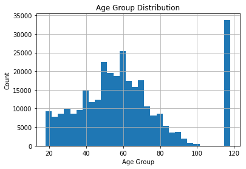

```python
data.age.hist(bins = 30)
plt.xlabel('Age Group')
plt.ylabel('Count')
plt.title('Age Group Distribution');
```

Outlier is present Age > 115 is present is high amount , which does not make sense .

```python
data.income.describe()
```

```
count    272762.000000
mean      64337.000755
std       21243.762941
min       30000.000000
25%       48000.000000
50%       62000.000000
75%       78000.000000
max      120000.000000
Name: income, dtype: float64
```

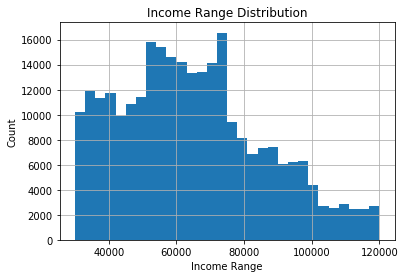

```python
data.income.hist(bins = 30);
plt.xlabel('Income Range')
plt.ylabel('Count')
plt.title('Income Range Distribution');
```

```python
data.gender.value_counts()
```

```
M    155690
F    113101
O      3971
Name: gender, dtype: int64
```

```python
male_proportion  = data.gender.value_counts()[0] / data.shape[0]*100
female_proportion = data.gender.value_counts()[1] / data.shape[0]*100
others_proportion = data.gender.value_counts()[2] / data.shape[0]*100

male_proportion ,female_proportion ,others_proportion
```

```
(50.790450651477492, 36.896722712651773, 1.2954517280301696)
```

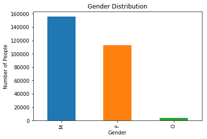

```python
ax = data.gender.value_counts()
ax.plot(kind='bar')
plt.ylabel('Number of People')
plt.xlabel('Gender')
plt.title('Gender Distribution');
```

```python
offer_received = data[data['offer-received'] == 1].offer_type.value_counts()
offer_viewed = data[data['offer-viewed'] == 1].offer_type.value_counts()
offer_completed = data[data['offer-completed'] == 1].offer_type.value_counts()

offer_received , offer_viewed , offer_completed
```

```
(discount         30543
 bogo             30499
 informational    15235
 Name: offer_type, dtype: int64, bogo             25449
 discount         21445
 informational    10831
 Name: offer_type, dtype: int64, discount    17910
 bogo        15669
 Name: offer_type, dtype: int64)
```

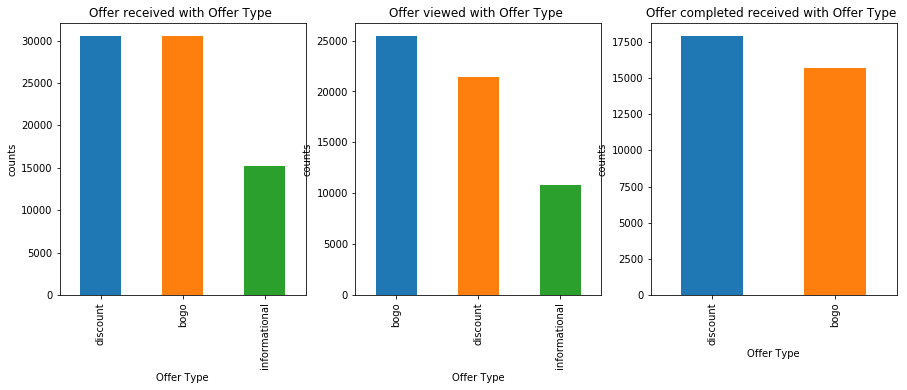

```python
plt.subplot(131)
offer_received = data[data['offer-received'] == 1].offer_type.value_counts()
offer_received.plot(kind='bar', figsize=(15,5))
plt.ylabel('counts')
plt.xlabel('Offer Type')
plt.title('Offer received with Offer Type ');

plt.subplot(132)
offer_viewed = data[data['offer-viewed'] == 1].offer_type.value_counts()
offer_viewed.plot(kind='bar' , figsize=(15,5))
plt.ylabel('counts')
plt.xlabel('Offer Type')
plt.title('Offer viewed with Offer Type ');

plt.subplot(133)
offer_completed = data[data['offer-completed'] == 1].offer_type.value_counts()
offer_completed.plot(kind='bar' , figsize=(15,5))
plt.ylabel('counts')
plt.xlabel('Offer Type')
plt.title('Offer completed received with Offer Type ');
```

```python
# For BOGO Offer :

R = offer_received[1]
V = offer_viewed[0]
C = offer_completed[1]

view_prop = V/R
com_prop = C/R
R , V , C , view_prop , com_prop
```

```
(30499, 25449, 15669, 0.83442080068198954, 0.51375454932948617)
```

```python
# For DISCOUNT Offer :

R = offer_received[0]
V = offer_viewed[1]
C = offer_completed[0]

view_prop = V/R
com_prop = C/R
R , V , C , view_prop , com_prop
```

```
(30543, 21445, 17910, 0.70212487312968597, 0.5863864060504862)
```

BOGO offers are highly demanding, the percentage of BOGO Offer viewer is 83 percent . The percentage of DISCOUNT Offer viewer is 70 percent .

```python
offer_received = data[data['offer-received'] == 1].offer_id.value_counts()
offer_viewed = data[data['offer-viewed'] == 1].offer_id.value_counts()
offer_completed = data[data['offer-completed'] == 1].offer_id.value_counts()

offer_received , offer_viewed , offer_completed
```

```
(0.0     7677
 5.0     7668
 3.0     7658
 10.0    7646
 7.0     7632
 2.0     7618
 6.0     7617
 8.0     7597
 9.0     7593
 4.0     7571
 Name: offer_id, dtype: int64, 10.0    7337
 8.0     7327
 9.0     7298
 4.0     7264
 3.0     6716
 2.0     6687
 0.0     4171
 6.0     4144
 7.0     4118
 5.0     2663
 Name: offer_id, dtype: int64, 8.0     5317
 10.0    5156
 0.0     4354
 4.0     4296
 7.0     4017
 3.0     3688
 5.0     3420
 9.0     3331
 Name: offer_id, dtype: int64)
```

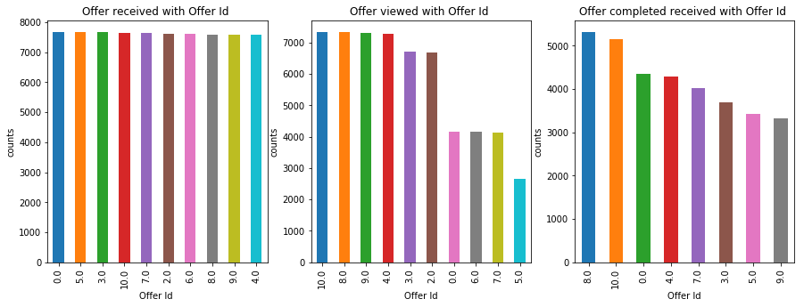

```python
plt.subplot(131)
offer_received = data[data['offer-received'] == 1].offer_id.value_counts()
offer_received.plot(kind='bar', figsize=(15,5))
plt.ylabel('counts')
plt.xlabel('Offer Id ')
plt.title('Offer received with Offer Id ');

plt.subplot(132)
offer_viewed = data[data['offer-viewed'] == 1].offer_id.value_counts()
offer_viewed.plot(kind='bar' , figsize=(15,5))
plt.ylabel('counts')
plt.xlabel('Offer Id')
plt.title('Offer viewed with Offer Id ');

plt.subplot(133)
offer_completed = data[data['offer-completed'] == 1].offer_id.value_counts()
offer_completed.plot(kind='bar' , figsize=(15,5))
plt.ylabel('counts')
plt.xlabel('Offer Id')
plt.title('Offer completed received with Offer Id ');
```

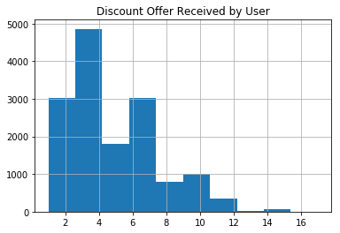

```python
data[data['offer_type']=='discount'].groupby('customer_id')['offer-completed'].count()
data[data['offer_type']=='discount'].groupby('customer_id')['offer-completed'].count().hist();
plt.title('Discount Offer Received by User');
```

# Modeling and Predictions :

```python
genders = {'O': 0, 'M': 1, 'F': 2}
data['gender'] = data['gender'].map(genders)
```

```python
data.offer_type.value_counts()
```

[output not shown]

```python
offers = {'bogo': 0, 'discount': 1, 'informational': 2}
data['offer_type'] = data['offer_type'].map(offers)
data.head()
```

[output not shown]

5 rows × 22 columns

```python
data.columns
```

```
Index(['event', 'customer_id', 'time', 'offer-completed', 'offer-received',
       'offer-viewed', 'transaction', 'offer_id', 'amount', 'age',
       'became_member_on', 'gender', 'income', 'difficulty', 'duration',
       'offer_type', 'reward', 'email', 'mobile', 'social', 'web', 'event_id'],
      dtype='object')
```

```python
X = data.drop(['customer_id', 'event_id' , 'event' , 'became_member_on','offer-completed', 'offer-received',
       'offer-viewed', 'transaction'], axis=1)
Y = data['event_id']
X.head()
```

[output not shown]

```python
Y.head()
```

```
0    0
1    1
2    2
3    3
4    2
Name: event_id, dtype: int64
```

```python
X.shape , Y.shape
```

```
((306534, 14), (306534,))
```

```python
class_name =['offer recieved', 'offer viewed', 'transaction', 'offer completed']
```

```python
X_train, X_test, y_train, y_test = train_test_split(X, Y, test_size=0.3, random_state=42)
```

```python
X_train.shape, X_test.shape, y_train.shape, y_test.shape
```

```
((214573, 14), (91961, 14), (214573,), (91961,))
```

```python
std = StandardScaler()
```

```python
X_train = X_train.values
X_test = X_test.values
y_train = y_train.values
y_test = y_test.values
```

#### Build a model

```python
ann = keras.models.Sequential()


ann.add(keras.layers.Dense(32, input_dim=7, kernel_initializer = 'normal' ,activation='relu'))
ann.add(keras.layers.Dense(15, kernel_initializer = 'normal' ,activation='relu'))
ann.add(keras.layers.Dense(10, kernel_initializer = 'normal' ,activation='relu'))
ann.add(keras.layers.Dense(6, kernel_initializer = 'normal' ,activation='relu'))
ann.add(keras.layers.Dense(4, kernel_initializer = 'normal' ,activation = 'softmax'))
```

```python
ann.compile(optimizer = 'adam',
            loss = 'sparse_categorical_crossentropy',
            metrics = ['accuracy'])
```

```python
ann_history = ann.fit(X_train, y_train, validation_data=(X_test, y_test), epochs=15, batch_size=100 , verbose = 2)
```

[output not shown]

```python
ann.summary()
```

```
_________________________________________________________________
Layer (type)                 Output Shape              Param #
=================================================================
dense_6 (Dense)              (None, 32)                256
_________________________________________________________________
dense_7 (Dense)              (None, 15)                495
_________________________________________________________________
dense_8 (Dense)              (None, 10)                160
_________________________________________________________________
dense_9 (Dense)              (None, 6)                 66
_________________________________________________________________
dense_10 (Dense)             (None, 4)                 28
=================================================================
Total params: 1,005
Trainable params: 1,005
Non-trainable params: 0
_________________________________________________________________
```

```python
ann.evaluate(X_test , y_test)
```

```
[nan, 0.250660606125781]
```

```python
# TO PERFORM OF CHECK THE RESULT IN NEW DATA SET
# AS WE DON'T HAVE NEW DATA SET , CREATE ONE FROM TEST DATA SET
# HOW TO PREDICT THE PROBABILITY and CLASSES IN UNSEEN DATA


x_new = X_test[:3]
```

```python
# PROBABILITY OF EACH SET

y_prob = ann.predict(x_new)
y_prob.round(2)                        # RESULT IN 2 DECIMAL PLACE
```

```
array([[ nan,  nan,  nan,  nan],
       [ nan,  nan,  nan,  nan],
       [ nan,  nan,  nan,  nan]], dtype=float32)
```

```python
# CLASS OF EACH SET

y_pred = ann.predict_classes(x_new)
y_pred
```

```
array([0, 0, 0])
```

```python
np.array(class_name)[y_pred]
```

```
array(['offer recieved', 'offer recieved', 'offer recieved'],
      dtype='<U15')
```

# Conclusion:

- The events are wrongly predicted as 'offer received'